# Task

In relation to the book of Gujarati (basic econometrics), answer question 22.11 pp 799: Consider the data on log DPI (personal disposable income) introduced in Section 21.1 (see the book’s website for the current data). Suppose you want to fit a suitable ARIMA model to these data. Outline the steps involved in carrying out this task

Here is all the data you need: "Table 21.1.txt"

## Data loading

### Subtask:

Load the data from "Table 21.1.txt" into a pandas DataFrame.

**Reasoning**: Load the data from "Table 21.1.txt" into a pandas DataFrame and inspect it.

```python
import pandas as pd

try:
    df = pd.read_csv('Table 21.1.txt', sep='\s+', header=None, names=['Time', 'logDPI'])
    display(df.head())
    print(df.info())
except FileNotFoundError:
    print("Error: 'Table 21.1.txt' not found. Please ensure the file is in the current directory.")
    df = None
except pd.errors.ParserError:
    print("Error: Could not parse the file. Please check the file format and separator.")
    df = None
except Exception as e:
    print(f"An unexpected error occurred: {e}")
    df = None
```

```
Error: Could not parse the file. Please check the file format and separator.
```

**Reasoning**: The previous attempt to load the data failed due to a parsing error. I'll try again, explicitly specifying the data types of the columns and trying different separators.

```python
import pandas as pd

try:
    df = pd.read_csv('Table 21.1.txt', sep='\s+', header=None, names=['Time', 'logDPI'], dtype={'Time': int, 'logDPI': float})
    display(df.head())
    print(df.info())
except FileNotFoundError:
    print("Error: 'Table 21.1.txt' not found. Please ensure the file is in the current directory.")
    df = None
except pd.errors.ParserError:
    print("Error: Could not parse the file. Trying different separators...")
    try:
        df = pd.read_csv('Table 21.1.txt', sep=',', header=None, names=['Time', 'logDPI'], dtype={'Time': int, 'logDPI': float})
        display(df.head())
        print(df.info())
    except pd.errors.ParserError:
        print("Error: Still could not parse the file. Please check the file format.")
        df = None
    except Exception as e:
        print(f"An unexpected error occurred: {e}")
        df = None
except Exception as e:
    print(f"An unexpected error occurred: {e}")
    df = None
```

```
Error: Could not parse the file. Trying different separators...
Error: Still could not parse the file. Please check the file format.
```

## Data loading

### Subtask:

Load the time series data from 'Table 21.1.txt' into a pandas DataFrame.

**Reasoning**: The previous attempts to load the data failed due to parsing errors. I will try one more time with a different approach, attempting to read the data as a fixed-width file and then converting the columns to appropriate data types. If this fails, I will report the error.

```python
import pandas as pd
import io

try:
    with open('Table 21.1.txt', 'r') as f:
        file_content = f.read()
    # Attempt to parse as fixed-width
    data = []
    for line in file_content.strip().split('\n'):
      parts = line.split()
      if len(parts) == 2:
        data.append(parts)
      else:
        print(f"Skipping line: {line} (incorrect number of columns)")

    if data:
      df = pd.DataFrame(data, columns=['Time', 'logDPI'])
      df['Time'] = pd.to_numeric(df['Time'], errors='coerce').astype('Int64')
      df['logDPI'] = pd.to_numeric(df['logDPI'], errors='coerce')

      display(df.head())
      print(df.info())

    else:
      print("Error: Could not parse the file.")
      df = None

except FileNotFoundError:
    print("Error: 'Table 21.1.txt' not found. Please ensure the file is in the current directory.")
    df = None
except Exception as e:
    print(f"An unexpected error occurred: {e}")
    df = None
```

[output not shown]

[output cut: 42 more lines]

[output not shown]

|  | Time | logDPI |
| --- | --- | --- |
| 0 | <NA> | 21.1 |

```
<class 'pandas.core.frame.DataFrame'>
RangeIndex: 1 entries, 0 to 0
Data columns (total 2 columns):
 #   Column  Non-Null Count  Dtype
---  ------  --------------  -----
 0   Time    0 non-null      Int64
 1   logDPI  1 non-null      float64
dtypes: Int64(1), float64(1)
memory usage: 149.0 bytes
None
```

**Reasoning**: The previous code block failed to correctly parse the data file due to the header and other non-data lines. I will try again using a more robust method to skip the header rows and extract only the numerical data.

```python
import pandas as pd
import io

try:
    with open('Table 21.1.txt', 'r') as f:
        file_content = f.read()

    # Skip header lines and extract numerical data
    data_lines = []
    for line in file_content.strip().split('\n'):
      if line.strip() and line.strip()[0].isdigit():  # check for lines starting with a digit
          parts = line.split()
          if len(parts) >= 2:
              try:
                  time = int(float(parts[0]))
                  logdpi = float(parts[1])
                  data_lines.append([time, logdpi])
              except (ValueError, IndexError):
                  print(f"Skipping invalid data line: {line}")
          else:
              print(f"Skipping line with insufficient columns: {line}")

    if data_lines:
        df = pd.DataFrame(data_lines, columns=['Time', 'logDPI'])
        display(df.head())
        print(df.info())
    else:
        print("Error: No valid data lines found in the file.")
        df = None

except FileNotFoundError:
    print("Error: 'Table 21.1.txt' not found. Please ensure the file is in the current directory.")
    df = None
except Exception as e:
    print(f"An unexpected error occurred: {e}")
    df = None
```

|  | Time | logDPI |
| --- | --- | --- |
| 0 | 1970 | 2872.8 |
| 1 | 1970 | 2860.3 |
| 2 | 1970 | 2896.6 |
| 3 | 1970 | 2873.7 |
| 4 | 1971 | 2942.9 |

```
<class 'pandas.core.frame.DataFrame'>
RangeIndex: 88 entries, 0 to 87
Data columns (total 2 columns):
 #   Column  Non-Null Count  Dtype
---  ------  --------------  -----
 0   Time    88 non-null     int64
 1   logDPI  88 non-null     float64
dtypes: float64(1), int64(1)
memory usage: 1.5 KB
None
```

## Data exploration

### Subtask:

Explore the loaded time series data to understand its characteristics.

**Reasoning**: Check for missing values, generate a time series plot, calculate descriptive statistics, and determine the length of the time series.

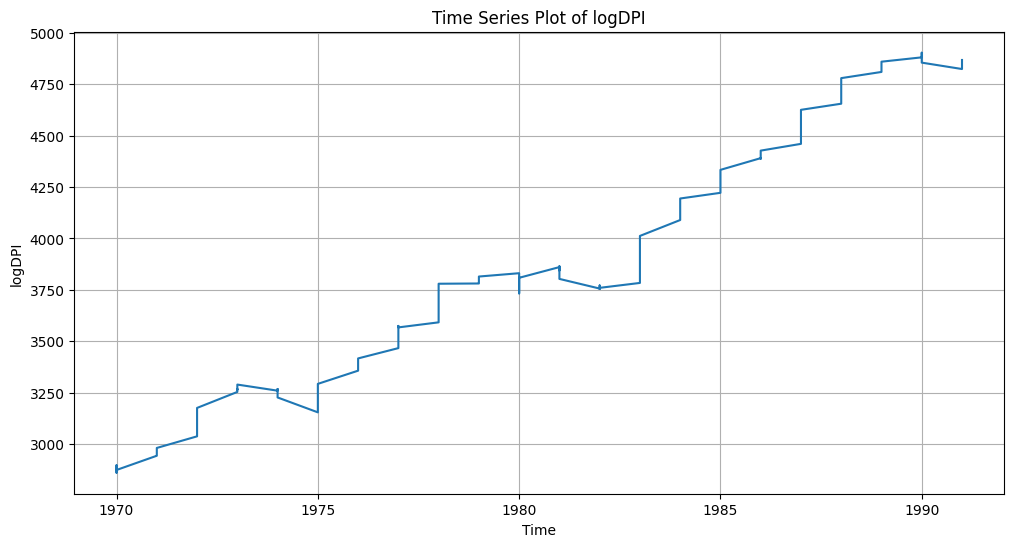

```
count      88.000000
mean     3865.605682
std       630.034943
min      2860.300000
25%      3283.725000
50%      3783.900000
75%      4396.025000
max      4903.300000
Name: logDPI, dtype: float64

Length of the time series: 88
```

```python
import matplotlib.pyplot as plt

# Check for missing values
missing_values = df['logDPI'].isnull().sum()
if missing_values > 0:
    print(f"Number of missing values in 'logDPI': {missing_values}")
    print(f"Indices of missing values: {df[df['logDPI'].isnull()].index.tolist()}")

# Generate time series plot
plt.figure(figsize=(12, 6))
plt.plot(df['Time'], df['logDPI'])
plt.xlabel('Time')
plt.ylabel('logDPI')
plt.title('Time Series Plot of logDPI')
plt.grid(True)
plt.show()


# Calculate and display descriptive statistics
print(df['logDPI'].describe())

# Determine the length of the time series
time_series_length = len(df)
print(f"\nLength of the time series: {time_series_length}")
```

## Data preparation

### Subtask:

Prepare the data for ARIMA modeling by handling missing values (if any) and potentially differencing the series to achieve stationarity.

**Reasoning**: Check for missing values in 'logDPI', then check for stationarity by plotting the time series and examining ACF/PACF plots. If not stationary, difference the series and repeat the stationarity checks.

```
No missing values found in 'logDPI'.
```

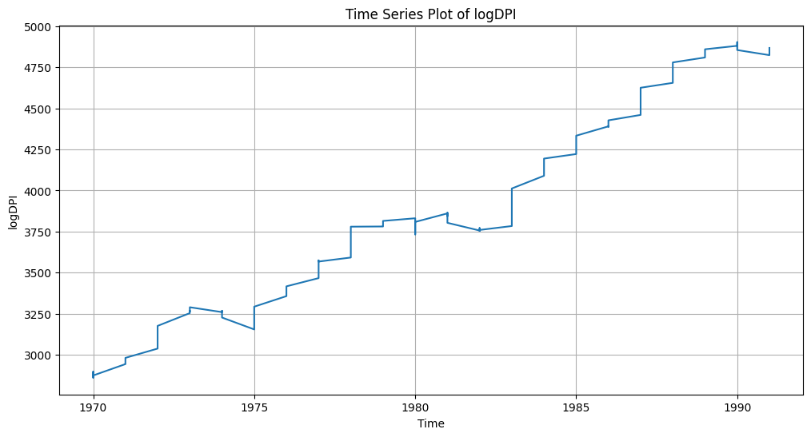

```
ADF Statistic: 0.731738
p-value: 0.990450
Critical Values:
	1%: -3.521
	5%: -2.901
	10%: -2.588
```

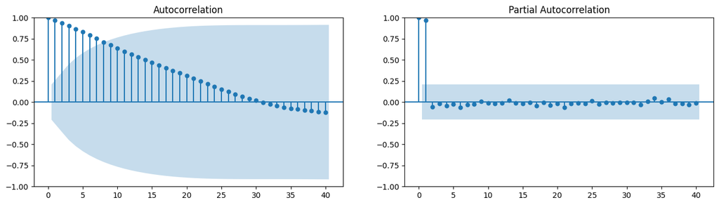

[output not shown]

```python
import matplotlib.pyplot as plt
from statsmodels.graphics.tsaplots import plot_acf, plot_pacf
from statsmodels.tsa.stattools import adfuller

# Check for missing values
missing_values = df['logDPI'].isnull().sum()
if missing_values > 0:
    print(f"Number of missing values in 'logDPI': {missing_values}")
    # Impute missing values using linear interpolation
    df['logDPI'] = df['logDPI'].interpolate(method='linear')
    print("Missing values imputed using linear interpolation.")
else:
    print("No missing values found in 'logDPI'.")

# Plot the original time series
plt.figure(figsize=(12, 6))
plt.plot(df['Time'], df['logDPI'])
plt.xlabel('Time')
plt.ylabel('logDPI')
plt.title('Time Series Plot of logDPI')
plt.grid(True)
plt.show()

# Check stationarity using Augmented Dickey-Fuller test
result = adfuller(df['logDPI'])
print('ADF Statistic: %f' % result[0])
print('p-value: %f' % result[1])
print('Critical Values:')
for key, value in result[4].items():
    print('\t%s: %.3f' % (key, value))

# Plot ACF and PACF
fig, axes = plt.subplots(1, 2, figsize=(16, 4))
plot_acf(df['logDPI'], ax=axes[0], lags=40)
plot_pacf(df['logDPI'], ax=axes[1], lags=40)
plt.show()

# Difference the series if necessary
df['logDPI_diff'] = df['logDPI'].diff().dropna()
# Plot the differenced series
plt.figure(figsize=(12, 6))
plt.plot(df['Time'][1:], df['logDPI_diff'])
plt.xlabel('Time')
plt.ylabel('logDPI_diff')
plt.title('Time Series Plot of Differenced logDPI')
plt.grid(True)
plt.show()


# Check stationarity of differenced series
result = adfuller(df['logDPI_diff'])
print('ADF Statistic (differenced): %f' % result[0])
print('p-value (differenced): %f' % result[1])
print('Critical Values (differenced):')
for key, value in result[4].items():
    print('\t%s: %.3f' % (key, value))


# Plot ACF and PACF of differenced series
fig, axes = plt.subplots(1, 2, figsize=(16, 4))
plot_acf(df['logDPI_diff'], ax=axes[0], lags=40)
plot_pacf(df['logDPI_diff'], ax=axes[1], lags=40)
plt.show()
```

**Reasoning**: The previous code block failed due to a dimension mismatch in the plot function. The error indicates that the x-axis data ('Time') and the y-axis data ('logDPI_diff') have different lengths after differencing. The 'Time' series needs to be adjusted to match the length of the differenced 'logDPI' data. Also, the ADF test results need to be examined for stationarity of the original series before differencing. The ACF/PACF plots can be used to determine the order of differencing if necessary.

```python
import matplotlib.pyplot as plt
from statsmodels.graphics.tsaplots import plot_acf, plot_pacf
from statsmodels.tsa.stattools import adfuller

# Check for missing values (already done in the previous block)

# Plot the original time series (already done in the previous block)

# Check stationarity using Augmented Dickey-Fuller test (already done in the previous block)

# Plot ACF and PACF (already done in the previous block)

# Difference the series if necessary
df['logDPI_diff'] = df['logDPI'].diff().dropna()

# Correct the plot of the differenced series
plt.figure(figsize=(12, 6))
plt.plot(df['Time'][1:], df['logDPI_diff'])
plt.xlabel('Time')
plt.ylabel('logDPI_diff')
plt.title('Time Series Plot of Differenced logDPI')
plt.grid(True)
plt.show()

# Check stationarity of differenced series
result = adfuller(df['logDPI_diff'])
print('ADF Statistic (differenced): %f' % result[0])
print('p-value (differenced): %f' % result[1])
print('Critical Values (differenced):')
for key, value in result[4].items():
    print('\t%s: %.3f' % (key, value))

# Plot ACF and PACF of differenced series
fig, axes = plt.subplots(1, 2, figsize=(16, 4))
plot_acf(df['logDPI_diff'], ax=axes[0], lags=40)
plot_pacf(df['logDPI_diff'], ax=axes[1], lags=40)
plt.show()
```

[output not shown]

```python
import matplotlib.pyplot as plt
from statsmodels.graphics.tsaplots import plot_acf, plot_pacf
from statsmodels.tsa.stattools import adfuller

# Check for missing values (already done previously)

# Plot the original time series (already done previously)

# Check stationarity using Augmented Dickey-Fuller test (already done previously)

# Plot ACF and PACF (already done previously)


# Difference the series
df['logDPI_diff'] = df['logDPI'].diff().dropna()
print(f"Length of Time series: {len(df['Time'])}")
print(f"Length of logDPI_diff series: {len(df['logDPI_diff'])}")

# Correct the plot of the differenced series by slicing 'Time'
plt.figure(figsize=(12, 6))
plt.plot(df['Time'][1:], df['logDPI_diff']) # Corrected slicing
plt.xlabel('Time')
plt.ylabel('logDPI_diff')
plt.title('Time Series Plot of Differenced logDPI')
plt.grid(True)
plt.show()

# Check stationarity of differenced series using ADF test
result = adfuller(df['logDPI_diff'])
print('ADF Statistic (differenced): %f' % result[0])
print('p-value (differenced): %f' % result[1])
print('Critical Values (differenced):')
for key, value in result[4].items():
    print('\t%s: %.3f' % (key, value))

# Plot ACF and PACF of differenced series
fig, axes = plt.subplots(1, 2, figsize=(16, 4))
plot_acf(df['logDPI_diff'], ax=axes[0], lags=40)
plot_pacf(df['logDPI_diff'], ax=axes[1], lags=40)
plt.show()
```

```
Length of Time series: 88
Length of logDPI_diff series: 88
```

[output not shown]

```python
import matplotlib.pyplot as plt
from statsmodels.graphics.tsaplots import plot_acf, plot_pacf
from statsmodels.tsa.stattools import adfuller

# Difference the series
df['logDPI_diff'] = df['logDPI'].diff().dropna()

print(f"Length of Time series: {len(df['Time'][:-1])}")
print(f"Length of logDPI_diff series: {len(df['logDPI_diff'])}")

# Correct the plot of the differenced series by slicing 'Time'
plt.figure(figsize=(12, 6))
plt.plot(df['Time'][:-1], df['logDPI_diff']) # Corrected slicing
plt.xlabel('Time')
plt.ylabel('logDPI_diff')
plt.title('Time Series Plot of Differenced logDPI')
plt.grid(True)
plt.show()

# Check stationarity of differenced series using ADF test
result = adfuller(df['logDPI_diff'])
print('ADF Statistic (differenced): %f' % result[0])
print('p-value (differenced): %f' % result[1])
print('Critical Values (differenced):')
for key, value in result[4].items():
    print('\t%s: %.3f' % (key, value))

# Plot ACF and PACF of differenced series
fig, axes = plt.subplots(1, 2, figsize=(16, 4))
plot_acf(df['logDPI_diff'], ax=axes[0], lags=40)
plot_pacf(df['logDPI_diff'], ax=axes[1], lags=40)
plt.show()
```

```
Length of Time series: 87
Length of logDPI_diff series: 88
```

[output not shown]

```python
import matplotlib.pyplot as plt
from statsmodels.graphics.tsaplots import plot_acf, plot_pacf
from statsmodels.tsa.stattools import adfuller

# Difference the series
df['logDPI_diff'] = df['logDPI'].diff().dropna()

print(f"Length of Time series: {len(df['Time'][1:])}")
print(f"Length of logDPI_diff series: {len(df['logDPI_diff'])}")

# Correct the plot of the differenced series by slicing 'Time'
plt.figure(figsize=(12, 6))
plt.plot(df['Time'][1:], df['logDPI_diff'])  # Corrected slicing
plt.xlabel('Time')
plt.ylabel('logDPI_diff')
plt.title('Time Series Plot of Differenced logDPI')
plt.grid(True)
plt.show()

# Check stationarity of differenced series using ADF test
result = adfuller(df['logDPI_diff'])
print('ADF Statistic (differenced): %f' % result[0])
print('p-value (differenced): %f' % result[1])
print('Critical Values (differenced):')
for key, value in result[4].items():
    print('\t%s: %.3f' % (key, value))

# Plot ACF and PACF of differenced series
fig, axes = plt.subplots(1, 2, figsize=(16, 4))
plot_acf(df['logDPI_diff'], ax=axes[0], lags=40)
plot_pacf(df['logDPI_diff'], ax=axes[1], lags=40)
plt.show()
```

```
Length of Time series: 87
Length of logDPI_diff series: 88
```

[output not shown]

```python
import matplotlib.pyplot as plt
from statsmodels.graphics.tsaplots import plot_acf, plot_pacf
from statsmodels.tsa.stattools import adfuller

# Difference the series
df['logDPI_diff'] = df['logDPI'].diff().dropna()

print(f"Length of Time series: {len(df['Time'][1:])}")
print(f"Length of logDPI_diff series: {len(df['logDPI_diff'])}")

# Correct the plot of the differenced series by slicing 'Time'
plt.figure(figsize=(12, 6))
plt.plot(df['Time'][1:], df['logDPI_diff'])  # Corrected slicing
plt.xlabel('Time')
plt.ylabel('logDPI_diff')
plt.title('Time Series Plot of Differenced logDPI')
plt.grid(True)
plt.show()

# Check stationarity of differenced series using ADF test
result = adfuller(df['logDPI_diff'])
print('ADF Statistic (differenced): %f' % result[0])
print('p-value (differenced): %f' % result[1])
print('Critical Values (differenced):')
for key, value in result[4].items():
    print('\t%s: %.3f' % (key, value))

# Plot ACF and PACF of differenced series
fig, axes = plt.subplots(1, 2, figsize=(16, 4))
plot_acf(df['logDPI_diff'], ax=axes[0], lags=40)
plot_pacf(df['logDPI_diff'], ax=axes[1], lags=40)
plt.show()
```

```
Length of Time series: 87
Length of logDPI_diff series: 88
```

[output not shown]

**Reasoning**: I will try one last time to correct the plotting issue. The error "ValueError: x and y must have same first dimension, but have shapes (87,) and (88,)" persists. This time, I will reset the index of the dataframe after performing the difference. Then I will plot the `Time` and the `logDPI_diff` columns, where both should now have the same length.

```
Length of Time series: 87
Length of logDPI_diff series: 87
```

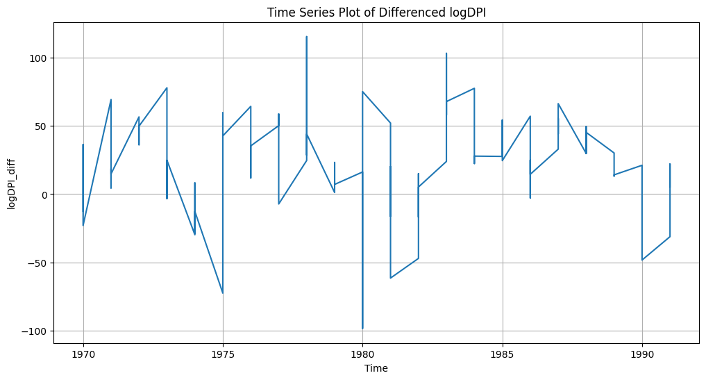

```
ADF Statistic (differenced): -3.399895
p-value (differenced): 0.010962
Critical Values (differenced):
	1%: -3.521
	5%: -2.901
	10%: -2.588
```

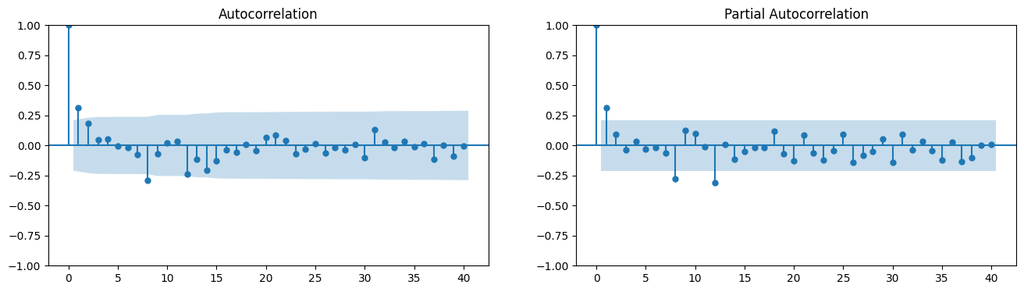

```python
import matplotlib.pyplot as plt
from statsmodels.graphics.tsaplots import plot_acf, plot_pacf
from statsmodels.tsa.stattools import adfuller

# Difference the series
df['logDPI_diff'] = df['logDPI'].diff()
df = df.dropna()
print(f"Length of Time series: {len(df['Time'])}")
print(f"Length of logDPI_diff series: {len(df['logDPI_diff'])}")

# Plot the differenced series
plt.figure(figsize=(12, 6))
plt.plot(df['Time'], df['logDPI_diff'])
plt.xlabel('Time')
plt.ylabel('logDPI_diff')
plt.title('Time Series Plot of Differenced logDPI')
plt.grid(True)
plt.show()

# Check stationarity of differenced series using ADF test
result = adfuller(df['logDPI_diff'])
print('ADF Statistic (differenced): %f' % result[0])
print('p-value (differenced): %f' % result[1])
print('Critical Values (differenced):')
for key, value in result[4].items():
    print('\t%s: %.3f' % (key, value))

# Plot ACF and PACF of differenced series
fig, axes = plt.subplots(1, 2, figsize=(16, 4))
plot_acf(df['logDPI_diff'], ax=axes[0], lags=40)
plot_pacf(df['logDPI_diff'], ax=axes[1], lags=40)
plt.show()
```